# 7 Antivirais 1 - Fármacos para Herpes simplex, Varicela-zóster e Citomegalovírus

O desenvolvimento de agentes antivirais representa um desafio terapêutico significativamente maior do que o de fármacos para combater bactérias ou fungos. A razão central para essa dificuldade reside na própria natureza dos vírus: eles dependem da replicação dentro do sistema do hospedeiro, utilizando a maquinaria bioquímica da própria célula para se multiplicar.

Essa dependência íntima cria o principal obstáculo da quimioterapia antiviral: como erradicar o vírus sem causar danos substanciais ao hospedeiro. Ao contrário dos antibacterianos, os fármacos antivirais frequentemente apresentam um índice terapêutico mais estreito , e a toxicidade – especialmente a nefrotoxicidade – é uma reação adversa comum.

Historicamente, o controle de doenças virais dependeu primariamente do desenvolvimento de vacinas. No entanto, uma nova era terapêutica começou em 1963 com a aprovação do primeiro fármaco antiviral humano, a **idoxuridina**. Este marco foi seguido de perto pelo licenciamento da **vidarabina**, o primeiro agente antiviral aprovado para o tratamento sistêmico de infecções por herpesvírus em humanos.

O grande avanço no tratamento de infecções da família Herpesviridae – incluindo o Herpes simplex, o Varicela-zóster e o Citomegalovírus – veio da capacidade de explorar as poucas, mas cruciais, diferenças entre os processos virais e os da célula hospedeira. A maioria dos agentes antivirais atuais interfere na síntese ou regulação dos ácidos nucleicos virais.

Fármacos como o **aciclovir**, um análogo de nucleosídeo amplamente utilizado para tratar infecções por herpesvírus, exemplificam essa estratégia. Seu mecanismo depende da fosforilação inicial por enzimas codificadas pelo vírus, como a timidina quinase, e só então é convertido à sua forma trifosfato ativa pelas enzimas da célula hospedeira. Este trifosfato atua como um substrato melhor para a DNA polimerase viral do que para a polimerase do hospedeiro, concentrando-se assim nas células infectadas e inibindo a replicação do DNA viral.

Este capítulo explorará em detalhes esses agentes, focando em como o design racional de fármacos permitiu a criação de moléculas que atingem alvos virais específicos, superando o desafio de tratar um inimigo que se esconde dentro de nossas próprias células.

## 7.1 Idoxuridina

A idoxuridina (5-iodo-2’-desoxiuridina) representa um marco histórico na quimioterapia antiviral, sendo o primeiro fármaco antiviral clinicamente aprovado com atividade seletiva. No final dos anos 1950, o farmacologista William H. Prusoff, trabalhando na Universidade de Yale, sintetizou este análogo da timidina como parte de suas pesquisas sobre nucleosídeos modificados. Inicialmente concebida como um potencial agente anticancerígeno sistêmico, a idoxuridina revelou-se excessivamente tóxica para essa aplicação. No entanto, seu mecanismo de ação — bloqueio seletivo da síntese de DNA viral — mostrou-se revolucionário quando o oftalmologista Herbert E. Kaufman descobriu, no início dos anos 1960, que o composto poderia ser usado efetivamente como tratamento tópico para ceratite herpética causada pelo vírus herpes simples. Esta descoberta mudou o paradigma científico ao demonstrar pela primeira vez que um fármaco antiviral poderia apresentar atividade seletiva clinicamente útil quando administrado adequadamente.

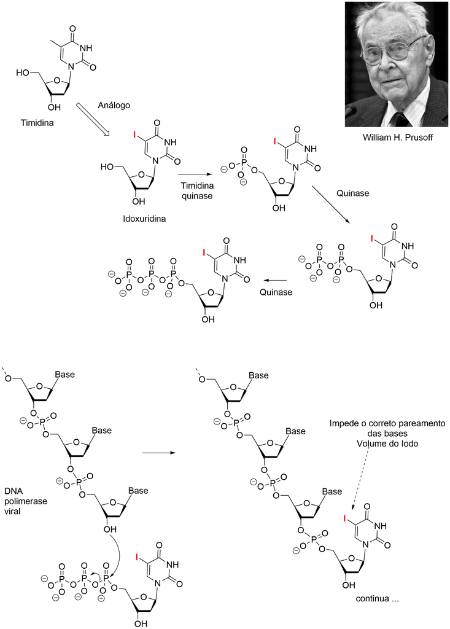

Figure 7.1: Transformação da timidina em idoxuridina, fosforilação pelas quinases celulares e incorporação do trifosfato de idoxuridina no DNA viral pela DNA polimerase, levando à interrupção da replicação viral devido ao volume do iodo e pareamento incorreto das bases.

A idoxuridina atua como um análogo da timidina que, após administração ocular, é convertida em suas formas mono-, di- e trifosfato. Uma vez fosforilada, ela é incorporada ao DNA viral em replicação, substituindo a timidina e causando disrupção da replicação viral. Este mecanismo mostrou-se eficaz contra vírus de DNA, particularmente o vírus herpes simples. Os estudos clínicos realizados por Kaufman em 1962 demonstraram a eficácia da idoxuridina no tratamento da ceratite herpética epitelial dendrítica. Com base nestas evidências promissoras, a Food and Drug Administration (FDA) dos Estados Unidos aprovou a idoxuridina em 1963 para o tratamento de herpes simples e varicela, estabelecendo-a como o primeiro agente antiviral aprovado para uso clínico. Este desenvolvimento pioneiro abriu caminho para a criação de toda uma geração subsequente de análogos nucleosídicos antivirais, solidificando o legado de Prusoff como o “pai da quimioterapia antiviral”.

A idoxuridina saiu de uso clínico principalmente devido à sua toxicidade relativamente alta para as células humanas e à baixa seletividade, além do surgimento de antivirais mais eficazes e seguros, como a vidarabina e, posteriormente, o aciclovir.

## 7.2 Vidarabina

A vidarabina (adenina 9-β-D-arabinofuranósida, também conhecida como ara-A representa um marco importante no desenvolvimento de antivirais, sendo originária de fontes marinhas naturais. Em meados dos anos 1960, a vidarabina foi isolada da esponja marinha *Tethya crypta* e posteriormente sintetizada pela Parke, Davis and Company (conforme consta na patente britânica No. 1.159.290). Estruturalmente, a vidarabina é um análogo purínico que substitui a ribose pela arabinose, conferindo propriedades antivirais únicas. Diferentemente da idoxuridina que apresentava alta toxicidade sistêmica, a vidarabina mostrou atividade contra uma gama mais ampla de vírus de DNA, incluindo herpes simplex, varicela-zóster e vírus vaccínia. Após aprovação pela FDA em 1976, a vidarabina tornou-se o primeiro antiviral aprovado para tratamento sistêmico de infecções por herpesvírus, particularmente para encefalite herpética, representando um avanço significativo em relação aos antivirais tópicos anteriores.

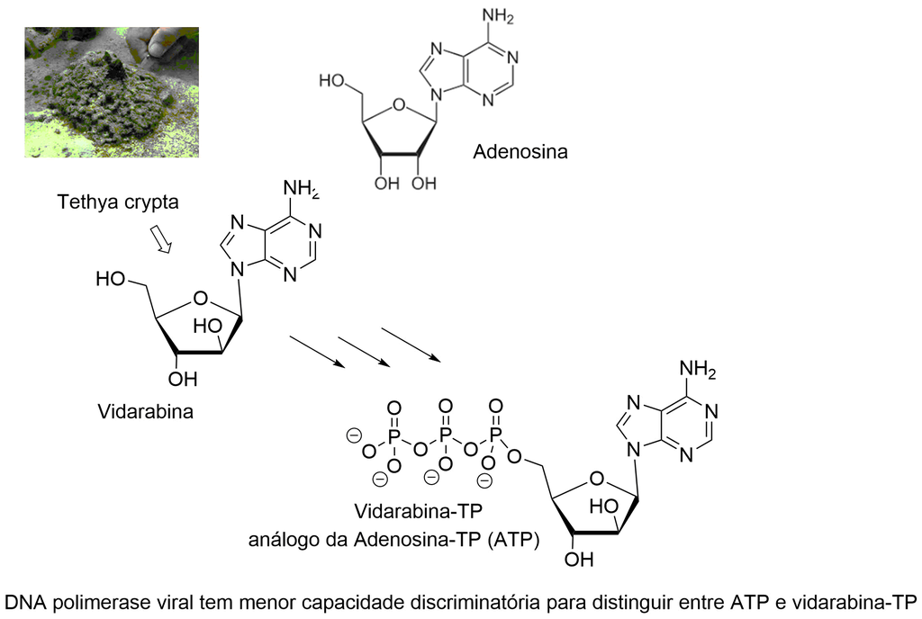

Figure 7.2: Isolamento da vidarabina da esponja marinha Tethya crypta, estrutura comparativa com adenosina, fosforilação em trifosfato pela quinase e mecanismo de engano da DNA polimerase viral pela similaridade estrutural com ATP, diferenciando-se apenas pela substituição da ribose por arabinose.

O sucesso da vidarabina foi, porém, eclipsado pelo surgimento do aciclovir, que recebeu aprovação da FDA em 1981. Embora a vidarabina apresentasse eficácia documentada contra herpesvírus, o aciclovir demonstrou superioridade em eficácia e perfil de segurança, levando à substituição gradual da vidarabina na prática clínica. A vidarabina requer fosforilação pela timidina quinase viral para ser ativada, gerando seu trifosfato (ara-ATP), que é então incorporado ao DNA viral pela DNA polimerase viral, bloqueando a síntese viral. No entanto, apresentava maior neurotoxicidade, exigindo infusão contínua em grandes volumes intravenosos devido à sua baixa solubilidade, e possuía uma janela terapêutica mais estreita comparada ao aciclovir. Apesar de seu declínio clínico para infecções virais, a vidarabina permanece de interesse científico atual, com pesquisas explorando seu potencial neuroprotensor em doenças neurodegenerativas como o Parkinson, bem como derivados prodrogas estão sendo desenvolvidos para melhorar sua biodisponibilidade oral.

## 7.3 Aciclovir: O Triunfo do Design Racional

Até ao final da década de 1970, a quimioterapia antiviral era um campo frustrante, limitado por fármacos de baixa eficácia e alta toxicidade. A maioria das descobertas seguia um método tradicional de “tentativa e erro”.

Esta realidade mudou drasticamente graças à nova abordagem de investigação farmacológica desenvolvida por **Gertrude B. Elion** e **George H. Hitchings** na Burroughs Wellcome. Em vez de procurar “balas mágicas” ao acaso, a sua equipa focou-se no design racional de fármacos. A sua estratégia baseava-se na compreensão das diferenças fundamentais entre o metabolismo das células humanas e o dos patógenos (como células cancerígenas, bactérias e vírus).

Eles especializaram-se no estudo do metabolismo das purinas e pirimidinas, com o objetivo de criar “antimetabólitos”: compostos sintéticos suficientemente semelhantes aos blocos de construção do DNA para serem “aceitos” pelas enzimas do patógeno, mas suficientemente diferentes para bloquear a sua replicação.

Foi esta filosofia que levou à descoberta do aciclovir.

**A Descoberta: O Legado de Elion** Após a reforma de Hitchings em 1967, Farmacêutica Gertrude Elion assumiu a chefia do Departamento de Terapia Experimental. Foi o seu grupo que formulou o aciclovir. A descoberta, relatada em 1974, não foi um acaso, mas o resultado de uma linha de investigação lógica: A equipa observou que um nucleosídeo de adenina (ara-A) possuía atividade antiviral. Isto levou Elion a reconsiderar um composto anterior, a diaminopurina, que tinha mostrado atividade antiviral surpreendente anos antes, mas fora abandonada por ser demasiado tóxica. Ao investigar análogos, sintetizaram um derivado que, em modelos animais, se convertia num análogo de guanina (ara-G). Seguindo esta pista, o grupo obteve o análogo de guanina “aciclovir”, que se revelou muito mais ativo in vivo. O aciclovir tornou-se o primeiro agente antiviral verdadeiramente seletivo contra a infeção por herpes , um feito que contribuiu diretamente para que Elion e Hitchings recebessem o Prémio Nobel de Fisiologia ou Medicina em 1988. O mecanismo do aciclovir é a prova máxima do sucesso da abordagem de Elion. O fármaco em si é um pró-fármaco inativo. A sua estrutura é um análogo da guanosina, mas falta-lhe a estrutura de anel de açúcar completa (especificamente os carbonos 2’ e 3’). A sua seletividade notável, que poupa as células não infetadas, deve-se a um processo de ativação em duas fases:

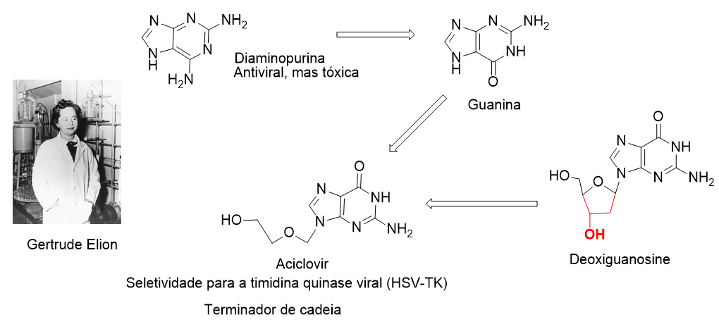

Figure 7.3

**Fosforilação Viral (O Passo-Chave):** O aciclovir só é ativado em células infetadas pelo vírus do herpes. Isto acontece porque a primeira fosforilação (para aciclovir monofosfato) é realizada de forma muito eficiente por uma enzima produzida pelo próprio vírus: a timidina quinase viral. As enzimas das células hospedeiras normais são muito menos eficientes a realizar este passo.

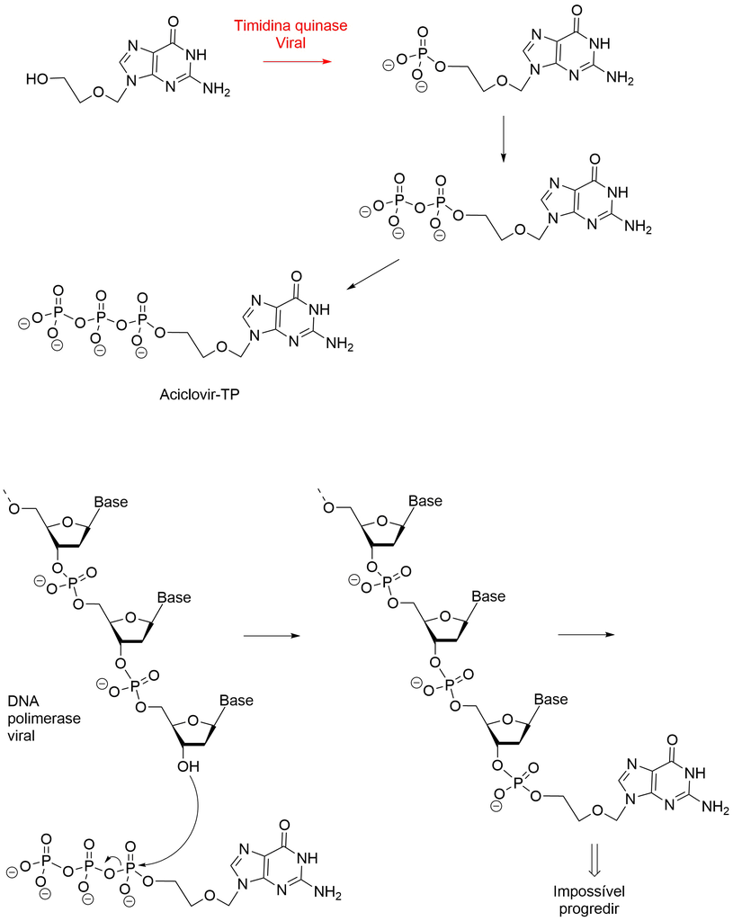

Figure 7.4: O esquema superior ilustra a bioativação seletiva do aciclovir. Inicialmente, o aciclovir (molécula superior esquerda) é fosforilado pela timidina quinase viral, formando o aciclovir monofosfato. As quinases celulares do hospedeiro convertem-no sequencialmente em aciclovir difosfato e, finalmente, em aciclovir trifosfato (Aciclovir-TP), a forma ativa do fármaco. O esquema inferior demonstra a interrupção da replicação do DNA viral pelo Aciclovir-TP. O trifosfato de aciclovir compete com os nucleotídeos naturais e é incorporado na cadeia de DNA em crescimento pela DNA polimerase viral. Devido à sua estrutura análoga, que carece de um **grupo hidroxila 3’**, a incorporação do Aciclovir-TP resulta na terminação imediata da cadeia, impossibilitando a progressão da síntese do DNA viral.

**Fosforilação Celular:** Assim que o monofosfato é formado, as enzimas da célula hospedeira assumem o controlo, convertendo-o nas formas difosfato e, finalmente, trifosfato de aciclovir (a forma ativa). Como resultado, o fármaco ativo concentra-se seletivamente apenas dentro das células infetadas. Uma vez ativo, o trifosfato de aciclovir ataca o vírus de duas formas: Inibição da DNA Polimerase: Compete e inativa eficazmente a DNA polimerase viral. Terminação da Cadeia de DNA: É incorporado na nova cadeia de DNA viral em crescimento. No entanto, como lhe falta a estrutura de carbono 3’ necessária para a ligação do próximo nucleótido, a cadeia é terminada abruptamente.

O aciclovir apresenta bioavailability oral muito baixa (~10-20%) e é eliminado rapidamente pelos rins, requerendo doses altas e frequentes. Essa farmacocinética inadequada levou ao desenvolvimento de profármacos como valaciclovir e famciclovir, que possuem melhor absorção intestinal e conversão mais eficiente em aciclovir ativo. O aciclovir tem atividade muito fraca contra Citomagalovírus (CMV) porque o CMV não expressa timidina quinase viral eficiente, impedindo a fosforilação adequada do aciclovir. Isso levou ao desenvolvimento de ganciclovir, cidofovir e foscarnet como alternativas para infecções por CMV, deslocando completamente o aciclovir dessa indicação. Em casos de resistência os inibidores de Helicase-Primase (como Pritelivir) — com mecanismo independente de timidina quinase viral, supera essa ao resistência ao aciclovir.

## 7.4 Valaciclovir: O Pró-fármaco Otimizado

Embora o aciclovir tenha revolucionado o tratamento do herpes, o seu potencial clínico foi historicamente limitado por um obstáculo significativo: a sua baixa e variável biodisponibilidade oral. Esta característica farmacocinética exigia regimes de dosagem frequentes — como cinco administrações diárias para o herpes genital ou herpes zoster — o que frequentemente levava a uma fraca adesão ao tratamento por parte do paciente.

Para superar esta limitação, foi desenvolvido o valaciclovir, um pró-fármaco inteligentemente desenhado.

Quimicamente, o valaciclovir é o éster **L-valina** do aciclovir. Esta modificação é a chave para a sua farmacocinética superior. A adição do aminoácido L-valina permite que o valaciclovir utilize um mecanismo de transporte ativo na membrana da borda em escova intestinal. Especificamente, ele é transportado ativamente através da parede intestinal pelo transportador de peptídeos 1 (PEPT1), que o reconhece devido à sua semelhança estrutural com peptídeos e aminoácidos.

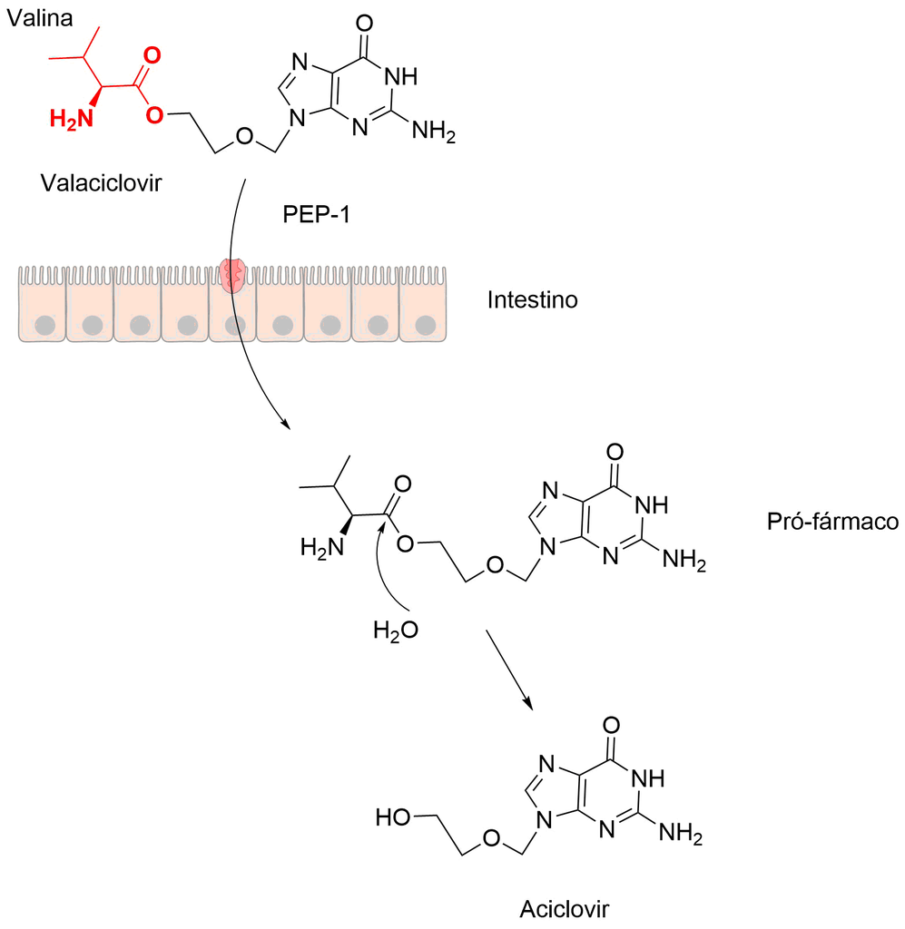

Figure 7.5: O valaciclovir é um pró-fármaco do tipo éster L-valina do aciclovir. A sua estrutura, contendo um aminoácido, permite que seja ativamente transportado através da parede intestinal pelo transportador de peptídeos 1 (PEP-1). Após a absorção, o valaciclovir sofre uma rápida hidrólise, que remove o grupo L-valina e liberta o fármaco antiviral ativo, o aciclovir, na corrente sanguínea.

Após a administração oral, o valaciclovir é rapidamente absorvido e sofre uma extensa conversão (hidrólise) durante o metabolismo intestinal e de primeira passagem hepática. Esta hidrólise liberta duas moléculas: o aciclovir (o composto antiviral ativo) e a L-valina, um aminoácido natural.

O resultado é um aumento de 3 a 5 vezes na biodisponibilidade do aciclovir em comparação com o que seria alcançável com a administração oral do próprio aciclovir. A biodisponibilidade absoluta do aciclovir após a toma de valaciclovir atinge 54,2%, sendo também mais previsível entre pacientes do que a do fármaco original.

Esta farmacocinética superior permite que o valaciclovir atinja níveis plasmáticos de aciclovir mais elevados e sustentados, permitindo regimes de dosagem muito mais convenientes e eficazes, mantendo o excelente perfil de segurança do aciclovir.

Herpes Genital (HSV): Para o tratamento agudo de episódios de herpes genital, o valaciclovir demonstrou ser tão eficaz com uma dosagem de duas vezes ao dia quanto o aciclovir administrado cinco vezes ao dia. Para a terapia supressiva (prevenção de recorrências), o valaciclovir é eficaz numa conveniente em única diária (500 mg).

Herpes Zoster (VZV): No tratamento do zoster, o valaciclovir (1000 mg três vezes ao dia) provou ser não só tão eficaz quanto o aciclovir (800 mg cinco vezes ao dia) na cicatrização das lesões, mas superior na aceleração da resolução da dor associada ao zoster e na redução da neuralgia pós-herpética.

## 7.5 Ganciclovir e Valganciclovir

O desenvolvimento do ganciclovir é inseparável da epidemia de AIDS no início dos anos 1980. O Citomegalovírus (CMV), um vírus da família do herpes, era até então considerado relativamente inofensivo, mas tornou-se uma infecção oportunista letal em pacientes imunocomprometidos, como os que tinham AIDS, causando frequentemente retinite, uma inflamação que levava rapidamente à cegueira. Em 1984, químicos da empresa farmacêutica Syntex sintetizaram um novo composto, mais tarde chamado ganciclovir, que demonstrava em laboratório uma característica única: era ativo contra o CMV, para o qual não havia tratamento.

O caminho do fármaco foi acelerado por um telefonema em maio de 1984, solicitando o seu “uso compassivo” para uma paciente transplantada que morria de pneumonia por CMV. Embora essa tentativa inicial não tenha tido sucesso, um segundo pedido em junho de 1984, para um paciente com AIDS (Paciente 02) que estava a ficar cego, mudou tudo. A retinite permitia aos médicos fotografar a retina e ver o fármaco a funcionar: a infeção melhorava com o tratamento, piorava quando este era interrompido e voltava a melhorar quando era reiniciado. Esta prova visível criou um “Catch-22” ético e regulatório; o ganciclovir era tão claramente eficaz que se tornou impossível realizar eticamente os ensaios controlados por placebo que a FDA exigia para a aprovação.

Apesar de a Syntex fornecer o fármaco gratuitamente a milhares de pacientes, a sua aplicação inicial à FDA foi rejeitada em 1987 por falta de um ensaio controlado. Só em 1989, após intensa pressão de ativistas da AIDS e uma reavaliação da agência, o ganciclovir foi finalmente aprovado, com base em grande parte nos dados de uso compassivo. O seu mecanismo de ação é distinto do aciclovir e explica a sua potência anti-CMV: o ganciclovir é um pró-fármaco que requer uma fosforilação inicial por uma quinase viral codificada pelo gene UL97 do CMV. Após as quinases celulares completarem a conversão para ganciclovir trifosfato, este inibe a DNA polimerase viral (UL54). Este metabolito ativo tem uma semi-vida intracelular longa, de 6 a 24 horas, o que contribui para a sua eficácia.

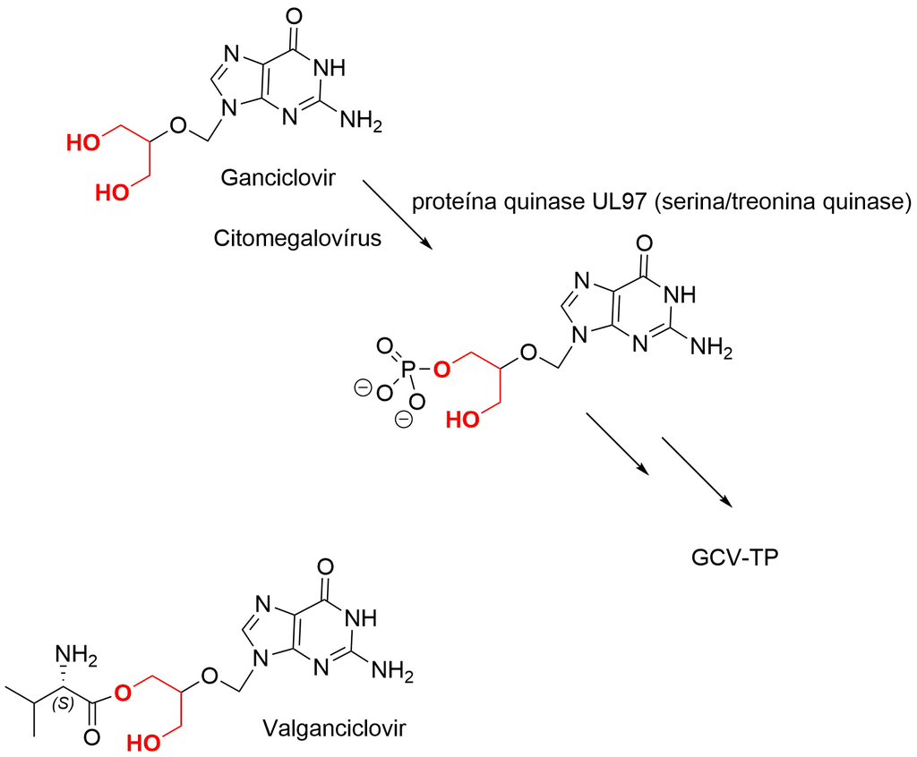

Figure 7.6: Mecanismo de Ativação do Ganciclovir pelo Citomegalovírus (CMV). O Ganciclovir, um análogo nucleosídico, é seletivamente fosforilado em células infectadas pelo Citomegalovírus. A proteína quinase UL97 (uma serina/treonina quinase) codificada pelo CMV é responsável pela primeira fosforilação do Ganciclovir em sua hidroxila primária (destacada em vermelho), formando o Ganciclovir Monofosfato. As fosforilações subsequentes, realizadas por quinases celulares, convertem o Ganciclovir Monofosfato nas formas difosfato e trifosfato (GCV-TP), que é a forma ativa e inibitória da DNA polimerase viral.

Embora o ganciclovir intravenoso fosse eficaz, a sua forma oral sofria de uma biodisponibilidade extremamente baixa, de apenas 6%, o que exigia doses grandes e frequentes. Para resolver este problema, foi desenhado um pró-fármaco: o **valganciclovir** Figure 7.6, o éster L-valina do ganciclovir. Esta modificação estrutural permite que o valganciclovir seja reconhecido e absorvido eficientemente por um sistema de transporte ativo de peptídeos no intestino, o PEPT1. Uma vez absorvido, é rapidamente hidrolisado, libertando ganciclovir na corrente sanguínea com uma biodisponibilidade 10 vezes superior, de aproximadamente 60%. Isto permitiu uma posologia oral conveniente, de dose única diária, com níveis de fármaco no sangue comparáveis aos da administração intravenosa.

## 7.6 Penciclovir e Famciclovir

O Penciclovir (PCV) é um potente agente antiviral desenvolvido pela SmithKline Beecham e sintetizado pela primeira vez em 1983. Demonstrou atividade contra vários membros da família do herpesvírus, incluindo o herpes simplex tipos 1 e 2 (HSV-1, HSV-2), o vírus varicela-zoster (VZV) e o vírus Epstein-Barr (EBV), bem como o vírus da hepatite B (HBV). O **Penciclovir** tópico foi licenciado como Denavir™ e Vectavir™ para o tratamento de herpes labial (“cold sores”), mas o seu desenvolvimento como agente oral enfrentou um obstáculo significativo.

O desafio central do penciclovir era a sua absorção oral “muito baixa”, um problema partilhado por outros análogos de nucleósidos como o ganciclovir. Estudos em animais previram que a absorção em humanos seria inadequada , o que foi confirmado em voluntários: a biodisponibilidade oral do penciclovir era de apenas 1-3% em ratos e cerca de 4% em humanos. Esta “característica chave” tornou essencial o desenvolvimento de um pró-fármaco eficaz.

A procura pelo pró-fármaco foi um exercício de design molecular metódico. Os cientistas perceberam que a baixa absorção estava ligada não apenas à polaridade, mas também à elevada “energia de rede” (lattice energy) da estrutura cristalina do penciclovir, causada por uma extensa rede de ligações de hidrogénio. Várias estratégias falharam, incluindo ésteres simples e análogos que seriam substratos da adenosina desaminase. A descoberta crucial foi o análogo 6-desoxi do penciclovir (BRL 42359). Este composto era eficientemente convertido em penciclovir no corpo, mas ainda assim mal absorvido. A equipe então mudou de estratégia: criar ésteres deste análogo 6-desoxi para melhorar a sua absorção.

Isto levou ao famciclovir (FCV) , o éster diacetil do 6-desoxipenciclovir. Esta modificação quebrou a rede de ligações de hidrogénio, resultando numa menor energia de rede, maior solubilidade e absorção vastamente melhorada. O Famciclovir foi selecionado em detrimento de outro candidato (o éster dipropionil, BRL 43599) após testes comparativos cruciais em tecidos humanos. O BRL 43599 era hidrolisado muito rapidamente (meia-vida de 7 min) no duodeno humano, o que poderia metabolizá-lo antes da absorção. O Famciclovir, com uma meia-vida de ~6,5 horas, era muito mais estável , garantindo tempo suficiente para ser absorvido intacto.

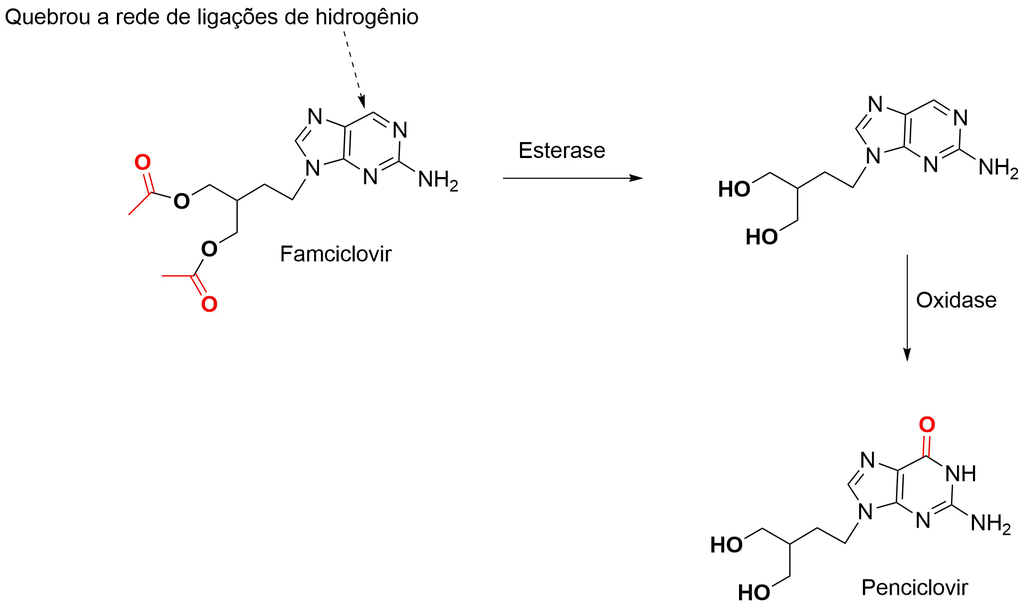

Figure 7.7: Mecanismo de Ativação do Famciclovir. O Famciclovir, um pró-fármaco, é o éster diacetil do 6-desoxipenciclovir. Os grupos acetil (destacados a vermelho) conferem lipofilicidade e quebram a rede de ligações de hidrogénio do penciclovir, melhorando drasticamente a sua absorção oral. Após a absorção, esterases removem os grupos acetil, formando 6-desoxipenciclovir. Uma oxidase (principalmente a aldeído oxidase) converte o 6-desoxipenciclovir no fármaco antiviral ativo, Penciclovir.

A conversão do famciclovir em penciclovir ocorre numa cascata de dois passos altamente eficiente: Após a absorção, o famciclovir passa pela parede intestinal, onde esterases removem os dois grupos acetil, convertendo-o em 6-desoxipenciclovir. Este intermediário segue para o fígado , onde uma enzima oxida a posição 6 do anel purina, formando o fármaco ativo, penciclovir.

Curiosamente, enquanto o pró-fármaco do aciclovir usa a xantina oxidase, os estudos revelaram que o passo final de oxidação do famciclovir em humanos é catalisado principalmente pela aldelído oxidase. O resultado desta estratégia é notável: a biodisponibilidade absoluta do penciclovir após a administração oral de famciclovir é de 77% , um aumento drástico em comparação com os ~4% do penciclovir oral.

O mecanismo de ação do penciclovir, uma vez formado, depende da sua ativação seletiva em células infetadas pelo herpesvírus. A quinase timidina (TK) viral, que tem uma afinidade muito alta pelo penciclovir (100 vezes maior que pelo aciclovir no caso do HSV-1) , realiza a primeira fosforilação para penciclovir-monofosfato. As quinases celulares então convertem-no na forma ativa, penciclovir-trifosfato (PCV-TP).

O penciclovir distingue-se do aciclovir em dois aspetos cruciais: Concentração: A fosforilação do penciclovir é extremamente eficiente, acumulando concentrações intracelulares massivas do trifosfato ativo (PCV-TP) , atingindo níveis muito superiores aos do aciclovir-trifosfato (ex: 300 µM vs 2,5 µM).

Estabilidade: O PCV-TP é “altamente estável” e persiste na célula infetada por longos períodos. A sua meia-vida intracelular é de 10 horas (HSV-1), 20 horas (HSV-2) e 9 horas (VZV). Em contraste, a meia-vida do aciclovir-trifosfato é de apenas ~1 hora.

Embora o PCV-TP seja um inibidor menos potente da DNA polimerase viral do que o aciclovir-TP (Ki ~100 vezes maior) , isto é totalmente compensado pelas concentrações intracelulares muito mais elevadas e pela estabilidade superior. Esta farmacologia intracelular única confere ao penciclovir um efeito antiviral prolongado , permitindo regimes de dosagem menos frequentes para o famciclovir em comparação com terapias mais antigas

## 7.7 Cidofovir

O Cidofovir [(S)-1-(3-hydroxy-2-phosphonylmethoxypropyl) cytosine, HPMPC] é o primeiro análogo de nucleótido antiviral a ser disponibilizado clinicamente. Originário da colaboração entre Antonín Holý em Praga e Erik De Clercq em Leuven, é um derivado do DHPA e do HPMPA. Diferente dos análogos de nucleósido como o ganciclovir, o cidofovir já possui um grupo fosfato (especificamente, um grupo fosfonato) e, portanto, não requer a fosforilação inicial por quinases virais, como a UL97 do CMV. A sua ativação para a forma difosfato ativa (contendo 3 grupos fosfato no total) ocorre através de duas fosforilações realizadas por quinases celulares, presentes tanto em células infetadas como não infetadas. O cidofovir difosfato inibe seletivamente a DNA polimerase viral, competindo com o substrato natural dCTP e reduzindo a taxa de síntese do DNA viral. A incorporação de uma molécula reduz modestamente a síntese, mas a incorporação de uma segunda molécula consecutiva (“tandem”) causa uma inibição acentuada, funcionando como um terminador de cadeia eficaz neste cenário. O Cidofovir exibe um largo espectro de atividade contra vírus DNA, incluindo polioma, papiloma, adeno, herpes (incluindo CMV e estirpes resistentes ao aciclovir) e poxvírus.

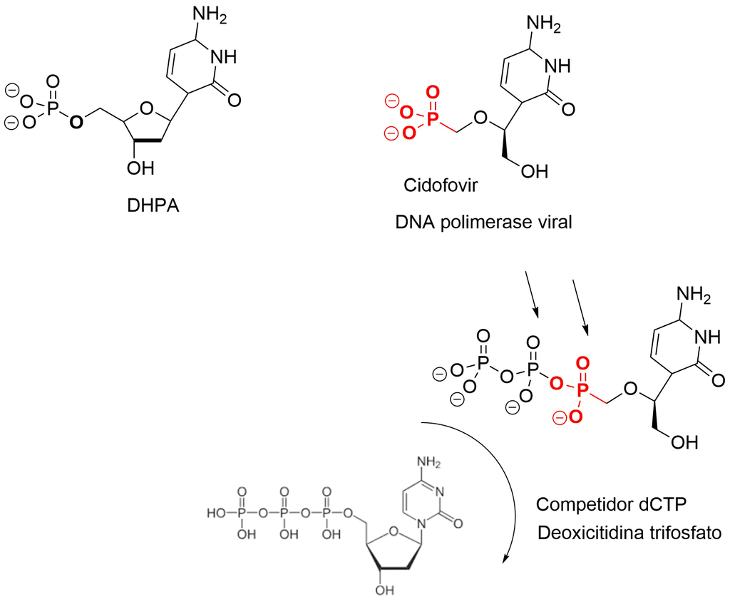

Figure 7.8: Mecanismo de Ação do Cidofovir. O Cidofovir, um análogo de nucleótido, é convertido intracelularmente por quinases celulares na sua forma ativa, o cidofovir difosfato (fosfatos destacados a vermelho). Este metabolito atua como um inibidor competitivo da DNA polimerase viral em relação ao substrato natural, desoxicitidina trifosfato (dCTP), e a sua incorporação no DNA viral reduz a taxa de síntese.

A principal indicação clínica do cidofovir (Vistide®) é o tratamento da retinite por CMV em pacientes com AIDS. Estudos clínicos demonstraram a sua eficácia em retardar a progressão da retinite em comparação com o tratamento diferido, tanto em pacientes não tratados previamente como naqueles com doença recidivante. Uma característica farmacocinética distintiva do cidofovir é a longa semi-vida intracelular do seu metabolito ativo, o cidofovir difosfato, estimada em cerca de 65 horas. Isto contrasta fortemente com a sua curta semi-vida no soro, de aproximadamente 2.5 horas. Esta prolongada persistência intracelular permite um regime de administração de manutenção pouco frequente, geralmente a cada duas semanas, o que representa uma vantagem em relação às infusões diárias necessárias para o ganciclovir ou foscarnet intravenosos. Esta posologia menos intrusiva pode evitar a necessidade de cateteres venosos centrais permanentes e o risco associado de infeções graves.

Apesar da sua eficácia e posologia conveniente, o uso do cidofovir é limitado por desafios de administração e toxicidade. Possui baixa biodisponibilidade oral (<5%), exigindo administração intravenosa. A principal toxicidade limitante da dose é a nefrotoxicidade, manifestada como proteinúria e/ou elevação da creatinina sérica, resultante de lesão nas células do túbulo proximal renal. Esta toxicidade é dose-dependente e, embora muitas vezes parcialmente reversível com a interrupção do tratamento , pode ser grave e levar à insuficiência renal aguda. Para mitigar este risco, é obrigatória a co-administração de **probenecida** oral em alta dose e hidratação intravenosa com soro fisiológico. Acredita-se que a probenecida reduza a concentração de cidofovir nas células tubulares renais ao inibir o seu transporte ativo. No entanto, a própria probenecida pode causar efeitos adversos como náuseas, vómitos, febre e erupção cutânea. Outros efeitos adversos significativos do cidofovir intravenoso incluem uveíte/irite anterior, reportada frequentemente (especialmente em dados pós-comercialização e potencialmente associada ao uso concomitante de inibidores da protease), e, menos comumente, hipotonia ocular, que pode levar à perda de visão.

## 7.8 Considerações finais

A quimioterapia antiviral para herpesvírus superou o desafio inerente de erradicar o vírus que depende da maquinaria celular, o que historicamente resultava em um índice terapêutico estreito e toxicidade, como a nefrotoxicidade. A era terapêutica começou com a idoxuridina em 1963, seguida pela vidarabina (1976), o primeiro agente aprovado para tratamento sistêmico de herpesvírus, embora ambos fossem limitados por toxicidade e baixa seletividade. O avanço decisivo veio com o design racional de fármacos, que levou ao aciclovir, um análogo de nucleosídeo que demonstra seletividade superior ao exigir a fosforilação inicial eficiente pela timidina quinase viral, concentrando-se em células infectadas e agindo como terminador da cadeia de DNA viral. Devido à baixa biodisponibilidade oral do aciclovir (~10-20%), o desenvolvimento de pró-fármacos foi crucial: o valaciclovir (éster L-valina) utiliza o transportador PEPT1 para aumentar a biodisponibilidade para 54,2%, e o famciclovir, pró-fármaco do penciclovir, alcança 77% de biodisponibilidade, sendo o penciclovir-trifosfato notável por sua longa meia-vida intracelular (10 a 20 horas). Para infecções por Citomegalovírus (CMV), contra o qual o aciclovir tem pouca atividade, o ganciclovir requer ativação pela quinase viral UL97, e seu pró-fármaco, o valganciclovir (também um éster L-valina), elevou dramaticamente sua biodisponibilidade oral para aproximadamente 60%. Finalmente, o cidofovir, um análogo de nucleótido, dispensa a fosforilação por quinases virais, mas sua toxicidade dose-dependente (nefrotoxicidade) exige co-administração obrigatória de probenecida para mitigar a lesão tubular renal.